# Nonparametric Analysis of UK Road Accidents

functional cp for each police force

Valeria Iapaolo

Oswaldo Morales

Riccardo Morandi

Abylai Orynbassar

```r
library(tidyverse)
library(conformalInference.fd)
library(roahd)
library(lubridate)
library(mgcv)
library(mgcViz)
```

```r
load("~/Documents/Nonparametric Statisics/Project/clean data/full_collisions.RData")
```

```r
glimpse(full_collisions)
```

```
Rows: 2,585,717
Columns: 37
$ accident_index                              <chr> "200501BS00001", "200501BS00002", "200501BS00…
$ accident_year                               <dbl> 2005, 2005, 2005, 2005, 2005, 2005, 2005, 200…
$ accident_reference                          <chr> "01BS00001", "01BS00002", "01BS00003", "01BS0…
$ location_easting_osgr                       <dbl> 525680, 524170, 524520, 526900, 528060, 52477…
$ location_northing_osgr                      <dbl> 178240, 181650, 182240, 177530, 179040, 18116…
$ longitude                                   <dbl> -0.191170, -0.211708, -0.206458, -0.173862, -…
$ latitude                                    <dbl> 51.48910, 51.52007, 51.52530, 51.48244, 51.49…
$ police_force                                <fct> Metropolitan Police, Metropolitan Police, Met…
$ accident_severity                           <fct> Serious, Slight, Slight, Slight, Slight, Slig…
$ number_of_vehicles                          <dbl> 1, 1, 2, 1, 1, 2, 2, 1, 2, 2, 1, 2, 1, 2, 1, …
$ number_of_casualties                        <dbl> 1, 1, 1, 1, 1, 1, 1, 2, 2, 5, 1, 1, 1, 1, 2, …
$ date                                        <date> 2005-01-04, 2005-01-05, 2005-01-06, 2005-01-…
$ day_of_week                                 <fct> Tuesday, Wednesday, Thursday, Friday, Monday,…
```

[output cut: 24 more lines]

we need to create the dataset in a way that they cotain all of the days and a zero if no crashes happened in that day:

```r
all_dates <- unique(full_collisions$date)
all_police_forces <- unique(full_collisions$police_force)

full_combinations <- expand.grid(date = all_dates, police_force = all_police_forces)

crashes_per_day_police <- full_combinations %>%
  left_join(full_collisions %>% group_by(date, police_force) %>% summarize(number_of_crashes = n()),
            by = c("date", "police_force")) %>%
  replace_na(list(number_of_crashes = 0))
glimpse(crashes_per_day_police)
```

```
Rows: 341,848
Columns: 3
$ date              <date> 2005-01-04, 2005-01-05, 2005-01-06, 2005-01-07, 2005-01-10, 2005-01-1…
$ police_force      <fct> Metropolitan Police, Metropolitan Police, Metropolitan Police, Metropo…
$ number_of_crashes <int> 58, 63, 64, 59, 67, 76, 86, 82, 57, 57, 85, 92, 82, 79, 64, 80, 78, 80…
```

```r
crashes_per_day_police <- crashes_per_day_police %>% mutate(day_of_year = yday(date),
                                                            day = factor(wday(date)),year = year(date))
```

removing the 29 of february for dimensioality problems in the vectors below

```r
crashes_per_day_police <- crashes_per_day_police %>% filter(!(month(date)==2 & day(date)==29))
```

```r
train_years <- ceiling(seq(2005,2021,by = 1.5))
cal_years <- seq(2006,2021,3)

df_train <- crashes_per_day_police %>% filter(year %in% train_years)
df_cal <- crashes_per_day_police %>% filter(year %in% cal_years)
df_test <- crashes_per_day_police %>% filter(year == 2022)
```

starting with a gam and mixed effects

```r
gam_train <- bam(number_of_crashes ~ day + year +
                                  s(day_of_year,k = 53, bs = "cr") +
                       s(police_force, bs = "re"),
                data = df_train, family=quasipoisson(), method='REML')
```

```r
summary(gam_train)
```

```
Family: quasipoisson
Link function: log

Formula:
number_of_crashes ~ day + year + s(day_of_year, k = 53, bs = "cr") +
    s(police_force, bs = "re")

Parametric coefficients:
              Estimate Std. Error t value Pr(>|t|)
(Intercept) 81.2959321  0.4499718  180.67   <2e-16 ***
day2         0.2543089  0.0040811   62.31   <2e-16 ***
day3         0.3038483  0.0040350   75.30   <2e-16 ***
day4         0.3109257  0.0040289   77.17   <2e-16 ***
day5         0.3146008  0.0040276   78.11   <2e-16 ***
day6         0.3942311  0.0039628   99.48   <2e-16 ***
day7         0.1876563  0.0041400   45.33   <2e-16 ***
year        -0.0396915  0.0002158 -183.97   <2e-16 ***
---
Signif. codes:  0 ‘***’ 0.001 ‘**’ 0.01 ‘*’ 0.05 ‘.’ 0.1 ‘ ’ 1

Approximate significance of smooth terms:
                  edf Ref.df       F p-value
s(day_of_year)  49.18   51.6   157.6  <2e-16 ***
s(police_force) 50.99   51.0 16496.4  <2e-16 ***
---
Signif. codes:  0 ‘***’ 0.001 ‘**’ 0.01 ‘*’ 0.05 ‘.’ 0.1 ‘ ’ 1

R-sq.(adj) =  0.851   Deviance explained = 80.6%
-REML = 3.5021e+05  Scale est. = 1.6704    n = 208780
```

```r
b <- getViz(gam_train)
```

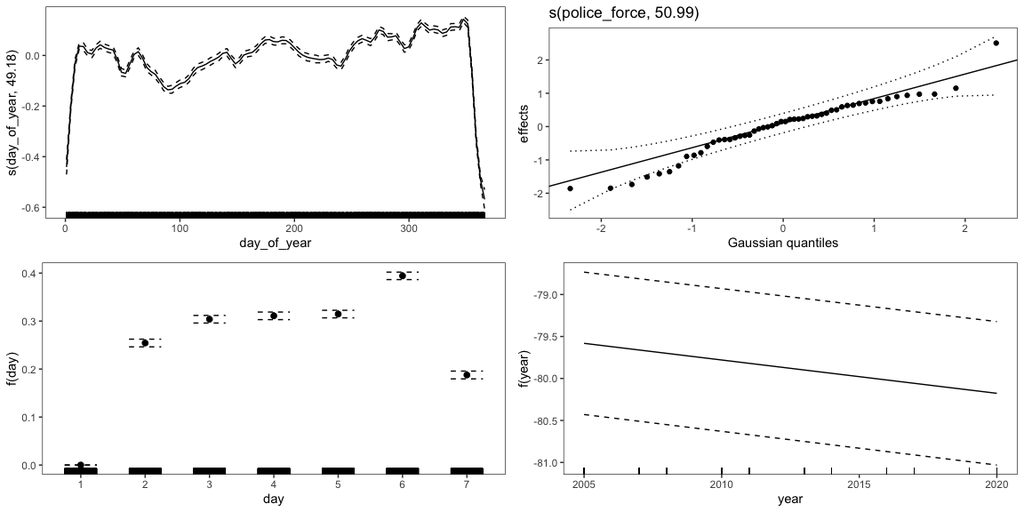

```r
print(plot(b, allTerms = T), pages = 1)
```

1 is sunday here

```
Method: REML   Optimizer: outer newton
full convergence after 7 iterations.
Gradient range [-0.1412846,0.14113]
(score 350205.1 & scale 1.670389).
Hessian positive definite, eigenvalue range [19.83786,104385.7].
Model rank =  112 / 112

Basis dimension (k) checking results. Low p-value (k-index<1) may
indicate that k is too low, especially if edf is close to k'.

                  k'  edf k-index p-value
s(day_of_year)  52.0 49.2    0.99    0.64
s(police_force) 52.0 51.0      NA      NA
```

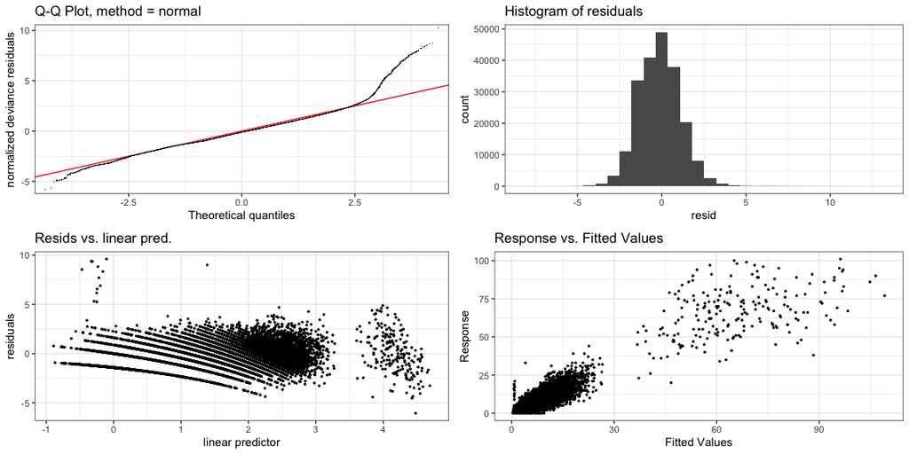

```r
check(b)
```

this is the best so far in terms of explained deviance, the residuals are not great

we now need to build the predictors and the bands manually

```r
res_train <- cbind(df_train,preds = predict(gam_train, df_train, type = "response")) %>%
  arrange(police_force,date) %>% mutate(absdiff = abs(number_of_crashes-preds))

res_cal <- cbind(df_cal,preds = predict(gam_train, df_cal, type = "response")) %>%
  arrange(police_force,date) %>% mutate(absdiff = abs(number_of_crashes-preds))

res_test <- cbind(df_test,preds = predict(gam_train, df_test, type = "response")) %>%
  arrange(police_force,date) %>% mutate(absdiff = abs(number_of_crashes-preds))
```

we now nee to compute the modulation functions and the k

```r
n_pol <- length(levels(crashes_per_day_police$police_force))

m = 12
l = 5
alpha = 0.1
kS = matrix(nrow = n_pol,ncol = 365)

x = 1:365
line_integral = function(x, y) {
  dx = diff(x)
  end = length(y)
  my = (y[1:(end - 1)] + y[2:end]) / 2
  sum(dx *my)
}

ceiling((m+1)*(1-alpha))
```

```
[1] 12
```

we use the largest value for gamma H1 = I1

```r
for(i in 1:n_pol){
  ad_cal <- res_cal %>% filter(police_force == levels(police_force)[i]) %>%
  dplyr::select(absdiff)
  a_mat <- matrix(ad_cal$absdiff,byrow = F,nrow = 365)
  ncm = apply(a_mat,1,max)
  den = line_integral(x, ncm)
  s = ncm/den
  ncs <- apply(a_mat/s,1,max)
  ncs_sort = c(sort(ncs))
  k = ncs_sort[ceiling((l + 1)*(1-alpha))]
  kS[i,] = k*s
}
```

testing for some police forces:

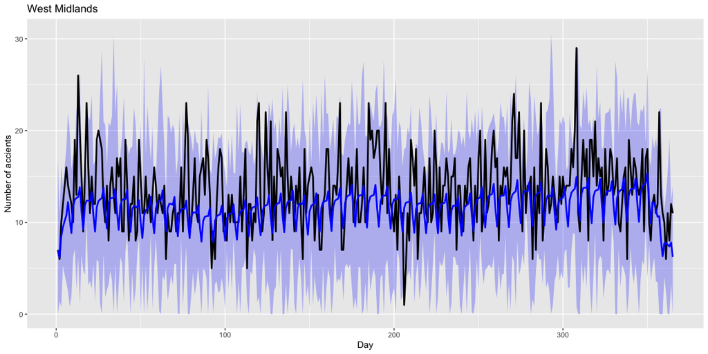

```r
i <- 50

df_filtered <- res_test %>% filter(police_force == levels(police_force)[i]) %>%
  arrange(day_of_year)

df_plot <- data.frame(n = df_filtered$number_of_crashes,pred = df_filtered$preds,
                      ymax = df_filtered$preds + kS[i,],
                      ymin = pmax( df_filtered$preds - kS[i,], rep(0, 365)),td = 1:365)

df_plot %>% ggplot() + geom_ribbon(aes(x=td,y = pred,ymin = ymin, ymax = ymax),
                                   fill = "blue", alpha = 0.25) +
  geom_line(aes(x=td,y = n),linewidth=1,colour = "black") +
  geom_line(aes(x=td,y = pred),linewidth=1,colour = "blue") + labs(x = "Day", y = "Number of accients",
                                                     title = levels(df_test$police_force)[i])
```

this are not great

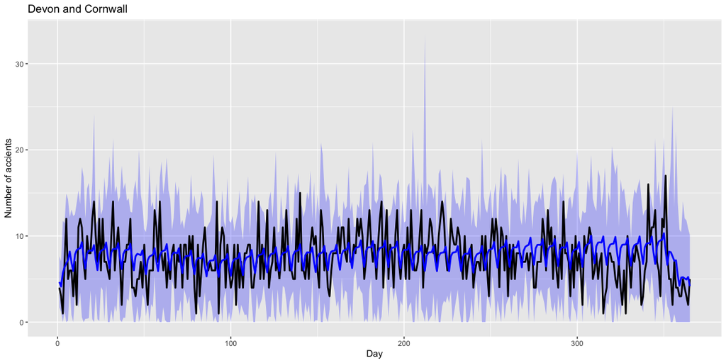

```r
i <- 10

df_filtered <- res_test %>% filter(police_force == levels(police_force)[i]) %>%
  arrange(day_of_year)

df_plot <- data.frame(n = df_filtered$number_of_crashes,pred = df_filtered$preds,
                      ymax = df_filtered$preds + kS[i,],
                      ymin = pmax( df_filtered$preds - kS[i,], rep(0, 365)),td = 1:365)

df_plot %>% ggplot() + geom_ribbon(aes(x=td,y = pred,ymin = ymin, ymax = ymax),
                                   fill = "blue", alpha = 0.25) +
  geom_line(aes(x=td,y = n),linewidth=1,colour = "black") +
  geom_line(aes(x=td,y = pred),linewidth=1,colour = "blue") + labs(x = "Day", y = "Number of accients",
                                                     title = levels(df_test$police_force)[i])
```

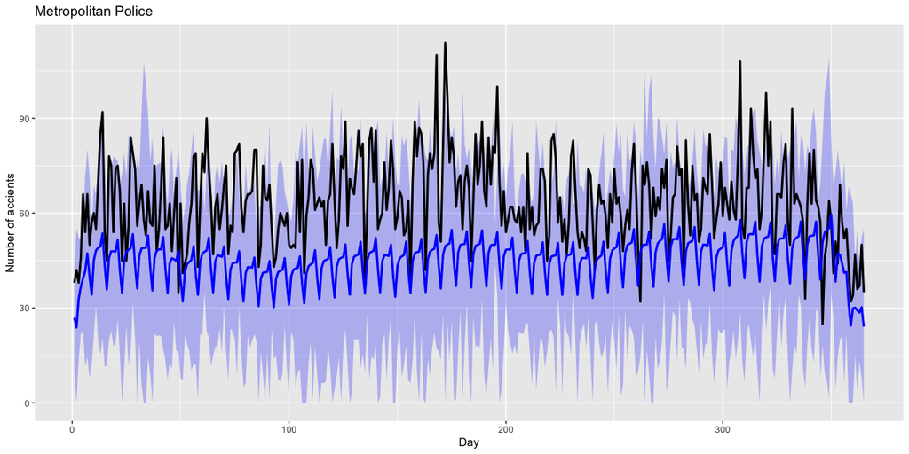

```r
i <- 30

df_filtered <- res_test %>% filter(police_force == levels(police_force)[i]) %>%
  arrange(day_of_year)

df_plot <- data.frame(n = df_filtered$number_of_crashes,pred = df_filtered$preds,
                      ymax = df_filtered$preds + kS[i,],
                      ymin = pmax( df_filtered$preds - kS[i,], rep(0, 365)),td = 1:365)

df_plot %>% ggplot() + geom_ribbon(aes(x=td,y = pred,ymin = ymin, ymax = ymax),
                                   fill = "blue", alpha = 0.25) +
  geom_line(aes(x=td,y = n),linewidth=1,colour = "black") +
  geom_line(aes(x=td,y = pred),linewidth=1,colour = "blue") + labs(x = "Day", y = "Number of accients",
                                                     title = levels(df_test$police_force)[i])
```

something is wrong. I think is the fact that we cannodd do this for mixed models since we don’t have the exchagnability assumption satisfied

we should fit a model for each police force separately.

doing it for Midlands.

```r
i <- 50
df_train_mid <- df_train %>% filter(police_force == levels(police_force)[i])
df_cal_mid <- df_cal %>% filter(police_force == levels(police_force)[i])
df_test_mid <- df_test %>% filter(police_force == levels(police_force)[i])
```

```r
gam_train_mid <- bam(number_of_crashes ~ day + year +
                                  s(day_of_year,k = 53, bs = "cr"),
                data = df_train_mid, family=quasipoisson(), method='REML')
```

```r
summary(gam_train_mid)
```

```
Family: quasipoisson
Link function: log

Formula:
number_of_crashes ~ day + year + s(day_of_year, k = 53, bs = "cr")

Parametric coefficients:
             Estimate Std. Error t value Pr(>|t|)
(Intercept) 91.152562   2.123058   42.94   <2e-16 ***
day2         0.287409   0.019918   14.43   <2e-16 ***
day3         0.306595   0.019822   15.47   <2e-16 ***
day4         0.318577   0.019772   16.11   <2e-16 ***
day5         0.328941   0.019740   16.66   <2e-16 ***
day6         0.400330   0.019456   20.58   <2e-16 ***
day7         0.222988   0.020189   11.04   <2e-16 ***
year        -0.044026   0.001055  -41.72   <2e-16 ***
---
Signif. codes:  0 ‘***’ 0.001 ‘**’ 0.01 ‘*’ 0.05 ‘.’ 0.1 ‘ ’ 1

Approximate significance of smooth terms:
                 edf Ref.df     F p-value
s(day_of_year) 24.89  30.53 10.55  <2e-16 ***
---
Signif. codes:  0 ‘***’ 0.001 ‘**’ 0.01 ‘*’ 0.05 ‘.’ 0.1 ‘ ’ 1

R-sq.(adj) =  0.404   Deviance explained = 39.3%
-REML =   6820  Scale est. = 1.6899    n = 4015
```

```r
b_mid <- getViz(gam_train_mid)
```

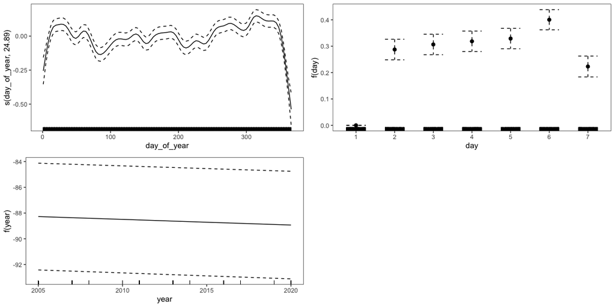

```r
print(plot(b_mid, allTerms = T), pages = 1)
```

1 is sunday here

```
Method: REML   Optimizer: outer newton
full convergence after 4 iterations.
Gradient range [-0.003214604,-0.0006275371]
(score 6820.006 & scale 1.689945).
Hessian positive definite, eigenvalue range [5.122104,2003.075].
Model rank =  60 / 60

Basis dimension (k) checking results. Low p-value (k-index<1) may
indicate that k is too low, especially if edf is close to k'.

                 k'  edf k-index p-value
s(day_of_year) 52.0 24.9    0.94  <2e-16 ***
---
Signif. codes:  0 ‘***’ 0.001 ‘**’ 0.01 ‘*’ 0.05 ‘.’ 0.1 ‘ ’ 1
```

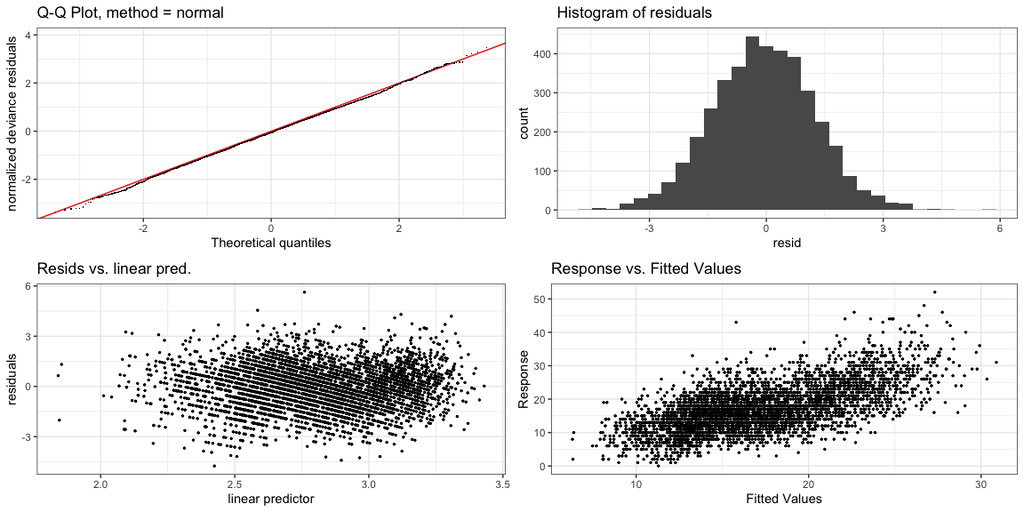

```r
check(b_mid)
```

```r
res_train_mid <- cbind(df_train_mid,preds = predict(gam_train_mid, df_train_mid, type = "response")) %>%
  arrange(date) %>% mutate(absdiff = abs(number_of_crashes-preds))

res_cal_mid <- cbind(df_cal_mid,preds = predict(gam_train_mid, df_cal_mid, type = "response")) %>%
  arrange(date) %>% mutate(absdiff = abs(number_of_crashes-preds))
```

we now nee to compute the modulation functions and the k

```r
m = 12
l = 5
alpha = 0.1
kS_mid = c()

x = 1:365
line_integral = function(x, y) {
  dx = diff(x)
  end = length(y)
  my = (y[1:(end - 1)] + y[2:end]) / 2
  sum(dx *my)
}

ad_train <- res_train %>% filter(police_force == levels(police_force)[i]) %>%
dplyr::select(absdiff)
a_mat <- matrix(ad_train$absdiff,byrow = F,nrow = 365)
ncm = apply(a_mat,1,max)
den = line_integral(x, ncm)
s = ncm/den
ad_cal <- res_cal %>% filter(police_force == levels(police_force)[i]) %>%
dplyr::select(absdiff)
a_mat <- matrix(ad_cal$absdiff,byrow = F,nrow = 365)
ncs <- apply(a_mat/s,1,max)
ncs_sort = c(sort(ncs))
k = ncs_sort[ceiling((l + 1)*(1-alpha))]
kS_mid = k*s
```

```r
preds_mid <- predict(gam_train_mid, df_test_mid, type = "response")
df_test_res <- cbind(df_test_mid,preds_mid) %>% arrange(day_of_year)
```

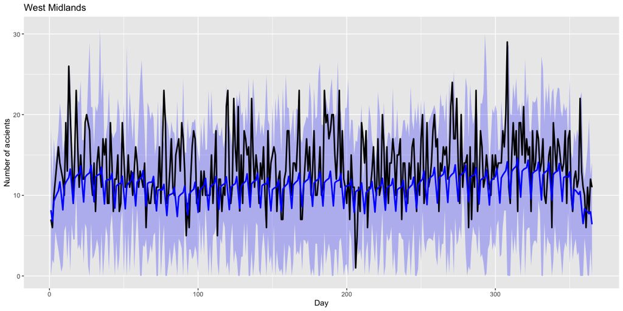

```r
df_plot <- data.frame(n = df_test_res$number_of_crashes,pred = df_test_res$preds,
                      ymax = df_test_res$preds + kS[i,],
                      ymin = pmax( df_test_res$preds - kS[i,], rep(0, 365)),td = 1:365)

df_plot %>% ggplot() + geom_ribbon(aes(x=td,y = pred,ymin = ymin, ymax = ymax),
                                   fill = "blue", alpha = 0.25) +
  geom_line(aes(x=td,y = n),linewidth=1,colour = "black") +
  geom_line(aes(x=td,y = pred),linewidth=1,colour = "blue") + labs(x = "Day", y = "Number of accients",
                                                     title = levels(df_test$police_force)[i])
```

this is ok here, not great.

trying for other police forces:

metropolitan police

```r
i <- 30
df_train_mid <- crashes_per_day_police %>% filter(year <=2016) %>%
  filter(police_force == levels(police_force)[i])
df_cal_mid <- crashes_per_day_police %>% filter(year > 2016) %>% filter(year < 2022)%>%
  filter(police_force == levels(police_force)[i])
df_test_mid <- crashes_per_day_police %>% filter(year == 2022)%>%
  filter(police_force == levels(police_force)[i])
```

```r
gam_train_mid <- bam(number_of_crashes ~ day + year +
                                  s(day_of_year,k = 53, bs = "cr"),
                data = df_train_mid, family=quasipoisson(), method='REML')
```

```r
summary(gam_train_mid)
```

```
Family: quasipoisson
Link function: log

Formula:
number_of_crashes ~ day + year + s(day_of_year, k = 53, bs = "cr")

Parametric coefficients:
             Estimate Std. Error t value Pr(>|t|)
(Intercept) 2.1062668  1.5125804   1.392    0.164
day2        0.2885544  0.0105645  27.314   <2e-16 ***
day3        0.3733047  0.0103755  35.979   <2e-16 ***
day4        0.3803747  0.0103641  36.701   <2e-16 ***
day5        0.3681157  0.0103867  35.441   <2e-16 ***
day6        0.4217614  0.0102782  41.035   <2e-16 ***
day7        0.2147289  0.0107309  20.010   <2e-16 ***
year        0.0008837  0.0007523   1.175    0.240
---
Signif. codes:  0 ‘***’ 0.001 ‘**’ 0.01 ‘*’ 0.05 ‘.’ 0.1 ‘ ’ 1

Approximate significance of smooth terms:
                 edf Ref.df     F p-value
s(day_of_year) 37.99  44.38 38.05  <2e-16 ***
---
Signif. codes:  0 ‘***’ 0.001 ‘**’ 0.01 ‘*’ 0.05 ‘.’ 0.1 ‘ ’ 1

R-sq.(adj) =  0.485   Deviance explained = 49.3%
-REML = 7785.7  Scale est. = 1.9513    n = 4380
```

```r
b_mid <- getViz(gam_train_mid)
```

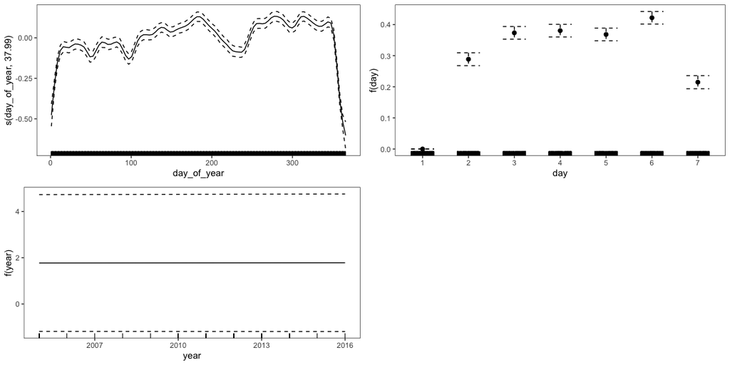

```r
print(plot(b_mid, allTerms = T), pages = 1)
```

1 is sunday here

```
Method: REML   Optimizer: outer newton
full convergence after 7 iterations.
Gradient range [-3.755108e-07,1.586546e-09]
(score 7785.691 & scale 1.951261).
Hessian positive definite, eigenvalue range [8.146088,2185.657].
Model rank =  60 / 60

Basis dimension (k) checking results. Low p-value (k-index<1) may
indicate that k is too low, especially if edf is close to k'.

               k' edf k-index p-value
s(day_of_year) 52  38    0.96  <2e-16 ***
---
Signif. codes:  0 ‘***’ 0.001 ‘**’ 0.01 ‘*’ 0.05 ‘.’ 0.1 ‘ ’ 1
```

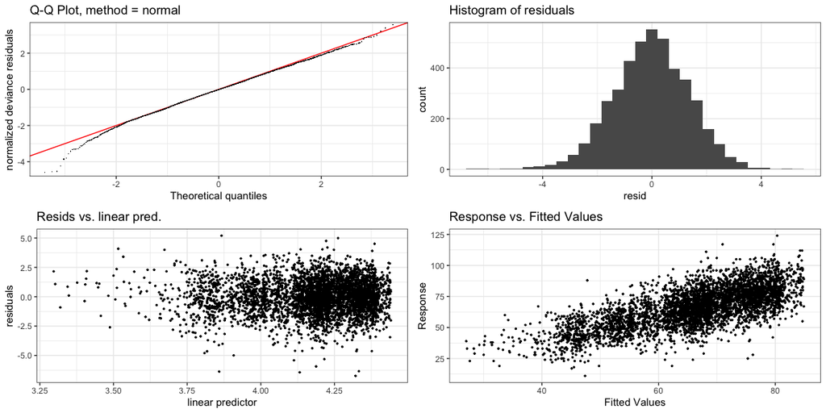

```r
check(b_mid)
```

```r
res_train_mid <- cbind(df_train_mid,preds = predict(gam_train_mid, df_train_mid, type = "response")) %>%
  arrange(date) %>% mutate(absdiff = abs(number_of_crashes-preds))

res_cal_mid <- cbind(df_cal_mid,preds = predict(gam_train_mid, df_cal_mid, type = "response")) %>%
  arrange(date) %>% mutate(absdiff = abs(number_of_crashes-preds))
```

we now nee to compute the modulation functions and the k

```r
m = 12
l = 5
alpha = 0.1
kS_mid = c()

x = 1:365
line_integral = function(x, y) {
  dx = diff(x)
  end = length(y)
  my = (y[1:(end - 1)] + y[2:end]) / 2
  sum(dx *my)
}

ad_train <- res_train %>% filter(police_force == levels(police_force)[i]) %>%
dplyr::select(absdiff)
a_mat <- matrix(ad_train$absdiff,byrow = F,nrow = 365)
ncm = apply(a_mat,1,max)
den = line_integral(x, ncm)
s = ncm/den
ad_cal <- res_cal %>% filter(police_force == levels(police_force)[i]) %>%
dplyr::select(absdiff)
a_mat <- matrix(ad_cal$absdiff,byrow = F,nrow = 365)
ncs <- apply(a_mat/s,1,max)
ncs_sort = c(sort(ncs))
k = ncs_sort[ceiling((l + 1)*(1-alpha))]
kS_mid = k*s
```

```r
preds_mid <- predict(gam_train_mid, df_test_mid, type = "response")
df_test_res <- cbind(df_test_mid,preds_mid) %>% arrange(day_of_year)
```

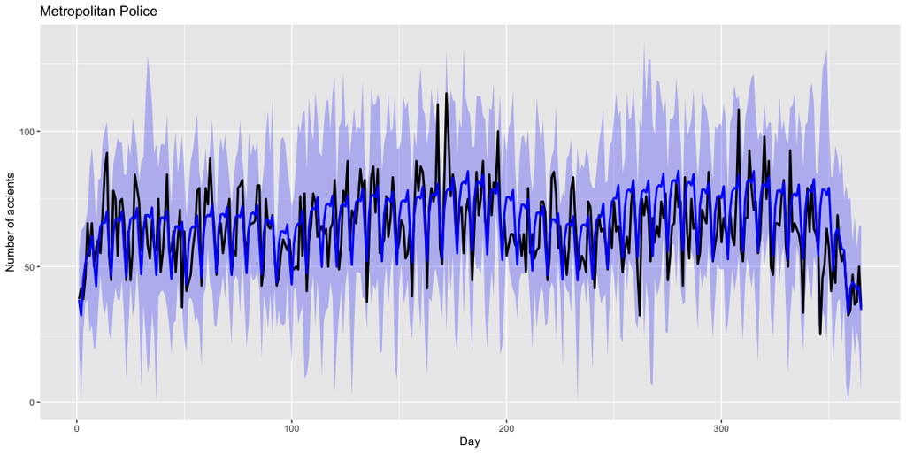

```r
df_plot <- data.frame(n = df_test_res$number_of_crashes,pred = df_test_res$preds,
                      ymax = df_test_res$preds + kS[i,],
                      ymin = pmax( df_test_res$preds - kS[i,], rep(0, 365)),td = 1:365)

df_plot %>% ggplot() + geom_ribbon(aes(x=td,y = pred,ymin = ymin, ymax = ymax),
                                   fill = "blue", alpha = 0.25) +
  geom_line(aes(x=td,y = n),linewidth=1,colour = "black") +
  geom_line(aes(x=td,y = pred),linewidth=1,colour = "blue") + labs(x = "Day", y = "Number of accients",
                                                     title = levels(df_test$police_force)[i])
```

the model seems to capture better the behaviour of the data in eack of the police departments.

check the computatios since done by hand.